# Unveiling Electoral Deception: An Investigation into Cheating Practices during Election 66

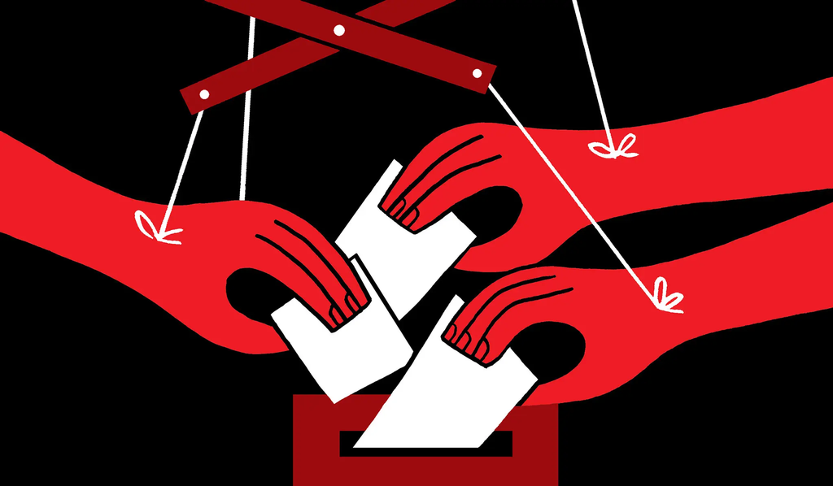

> ขอขอบคุณข้อมูลจากกกตที่ดึงมาโดยชุมชน ก้าวgeek [download](https://docs.google.com/spreadsheets/d/1WE1yZ6TeyS0-40TWS8OupULc8I_JiWTAo5fm3OCozIo/edit#gid=1155138857)

> แนวทางการวิเคราะห์ได้ไอเดียเริ่มต้นมาจากการวิคลิปบนยูทูบของช่อง[อาจารย์ ลอย ชุนพงษ์ทอง](https://www.youtube.com/@LoyAcademy)

> **disclaimer ยังไม่ได้ testโค้ดและทวนสอบข้อมูลอย่างถี่ถ้วน**

# 1 บทนำ

> อาจารย์ ลอย ชุนพงษ์ทอง (https://www.youtube.com/@LoyAcademy) ได้นำเสนอข้อมูลที่เป็นหลักฐานทางคณิตศาสตร์ที่ชี้ให้เห็นว่าการเปลี่ยนระบบเป็นกาบัตร 2 ใบ น่าจะมีส่วนอย่างมากทำให้มีพรรคการเมืองหน้าใหม่ทั้งหมด 6 พรรค ได้ ส.ส. ปัดเศษเข้าไปนั่งในสภา รวมไปถึงข้อมูลที่มีนัยยะทางคณิตศาสตร์ ว่าเขตที่ยิ่งมีการกาบัตรสลับใบมาก ยิ่งมีแน้วโน้มที่จะเกิดการทุจริการเลือกตั้งโดยการซื้อเสียงในเขตนั้นๆ หรือที่อาจารย์เรียกว่าทฤษฎีปลอกกระสุนปืน

> การทุจริตการเลือกตั้งโดยการซื้อเสียงมักจะทำโดยการซื้อเสียง ส.ส. เขตเนื่องจากใช้เงินลงทุนน้อยกว่ามากต่อ 1 ที่นั่งในสภา และชาวบ้านที่ถูกซื้อเสียงเหล่านั้นก็มักจะกาบัตร 2 ใบเป็นเลขเดียวกันเพื่อป้องกันความผิดพลาดและง่ายต่อการจดจำ นี่จึงเป็นเหตุที่ระบบกาบัตร 2 ใบจึงได้ทิ้งร่องรอย หรือที่อาจารย์ลอยเรียกว่าปลอกกระสุนทิ้งไว้เกลื่อนตามทาง

> ในบทความนี้เราจะนำเสนอข้อมูลที่นำไปสู่ข้อบ่งชี้ ที่ทำให้เห็นว่าผู้สมัคร ส.ส.เขตใดหรือพรรคการเมืองใด มีแนวโน้มที่จะทุจริตอย่างมีนัยยะสำคัญ ในขณะเดียวกันเราก็สามารถวิเคราะห์ในเชิงตรงข้ามว่าผู้สมัคร ส.ส. เขตและพรรคการเมืองใดที่น่าจะใสสะอาด ไร้ซึ่งร่องรอยแห่งปลอกกระสุนให้มีข้อต้องสงสัยใดๆเลย

> แต่ก่อนที่จะเริ่มอ่านบทวิเคราะห์นี้ ผู้อ่านจำเป็นต้องเข้าใจก่อนว่า บทวิเคราะห์ตั้งอยู่บนสมมุติฐานหลายข้อซึ่งยังไม่ได้มีการพิสูจน์ว่าเป็นความจริง อยากให้ผู้อ่านทุกคนเข้าใจหมายเหตุเหล่านี้ก่อนทั้งหมด 3 ข้อ
> 1. วิธีการซื้อเสียงที่มักจะกระทำโดยการให้กาเลขเดียวกัน 2 ใบ เป็นเพียงสมมติฐานที่ไม่สามารถพิสูจน์ได้เพียงการวิเคราะห์จากตัวเลข
> 2. คนที่กาเลขเดียวทั้ง 2 ใบอาจจะมีเหตุผลอื่นและไม่ได้ถูกซื้อเสียงก็เป็นได้
> 3. ตัวเลขบางอย่างสัมพันธ์กันแต่อาจะไม่ได้เป็นเหตุเป็นผลของกันและกัน

> *** **เพราะฉนั้นทั้งหมดนี้จึงเป็นเพียงสมมติฐาน และไม่สามารถใช้พิสูจน์ข้อเท็จจริงได้** ***

# 2 ผลการเลือกตั้งคะแนนบัญชีรายชื่อ

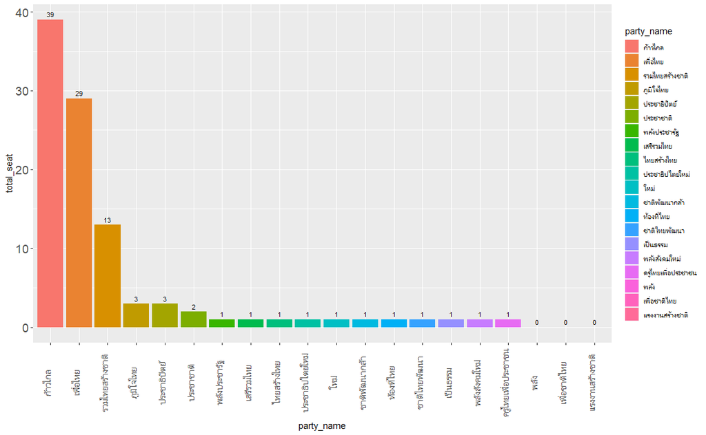

|  | เลขพรรค | พรรค | คะแนน | เปอร์เซ็นต์ | ที่นั่ง | เศษ | ที่นั่งปัดเศษ | รวมที่นั่ง |
| --- | --- | --- | --- | --- | --- | --- | --- | --- |
| 1 | 31 | ก้าวไกล | 14,233,895 | 38.47% | 38 | 0.47% | 1 | 39 |
| 2 | 29 | เพื่อไทย | 10,865,836 | 29.37% | 29 | 0.37% | 0 | 29 |
| 3 | 22 | รวมไทยสร้างชาติ | 4,673,691 | 12.63% | 12 | 0.63% | 1 | 13 |
| 4 | 7 | ภูมิใจไทย | 1,121,595 | 3.03% | 3 | 0.03% | 0 | 3 |
| 5 | 26 | ประชาธิปัตย์ | 899,303 | 2.43% | 2 | 0.43% | 1 | 3 |
| 6 | 11 | ประชาชาติ | 576,613 | 1.56% | 1 | 0.56% | 1 | 2 |
| 7 | 37 | พลังประชารัฐ | 530,017 | 1.43% | 1 | 0.43% | 0 | 1 |
| 8 | 25 | เสรีรวมไทย | 347,607 | 0.94% | 0 | 0.94% | 1 | 1 |
| 9 | 32 | ไทยสร้างไทย | 338,042 | 0.91% | 0 | 0.91% | 1 | 1 |
| 10 | 2 | ประชาธิปไตยใหม่ | 266,799 | 0.72% | 0 | 0.72% | 1 | 1 |

[output cut: 60 more lines]

> จากทั้งหมด 17 พรรคการเมืองที่ได้ที่นั่งบัญชีรายชื่อในสภา จะสังเกตุได้ว่าพรรคเบอร์ 1 ถึง 6 ล้วนได้ที่นั่ง ส.ส.ปัดเศษกันทั้งสิ้น หากมองเลยไปถึงพรรคหมายเลข 8 และหมายเลข 9 ถึงแม้ว่าทั้ง 2 พรรคจะไม่ได้ที่นั่งในสภา แต่ก็ยังมีคะแนนบัญชีรายชื่อก็อยู่ใน 20 อันดับแรกสูงสุด

> ทั้งหมดนี้เป็นเพราะความบังเอิญ หรือเป็นที่ข้อผิดพลาดของระบบเลือกตั้งบัตร 2 ใบกันแน่?

## 2.1 การกาสลับใบ

> หากสมมติฐานคือ พรรคเหล่านี้ได้อานิสงค์จากการกาสลับใบ หรือก็คือการที่ผู้ลงคะแนนเอาหมายเลข ส.ส.เขตไปกาคะแนนให้กับใบลงคะแนนบัญชีรายชื่อ ซึ่งหากเป็นเช่นนั้นเราก็ต้องถามต่อว่า แล้วทำไมหวยถึงมาออกที่พรรคหมายเลข 1 ถึง 6 คำตอบคือจริงๆแล้วพรรคอื่นๆตั้งแต่หมายเลข 7 ขึ้นไปก็ได้คะแนนส้มหล่นตรงนี้เช่นกัน เพียงแต่พรรคเลขยิ่งน้อยจะยิ่งได้อนิสงส์มาก

> เมื่อเราดูข้อมูลของผู้สมัคร ส.ส. เขตทั่วประเทศจะพบว่า ผู้สมัครที่มีหมายเลขสูงสุดคือหมายเลข 20 ซึ่งเป็นผู้สมัครจากพรรคคลองไทยในพื้นที่ขอนแก่นเขต 4

> แต่หากหากเราดูเฉพาะผู้สมัคร ส.ส. จาก 6 พรรคใหญ่พบหมายเลขสูงสุดคือหมายเลข 15 จำนวน 3 ท่าน ซึ่งเป็นผู้สมัครจากพรรคพลังประชารัฐและพรรคเพื่อไทยในจังหวัดกรุงเทพมหานคร

## 2.2 ผู้สมัครหมายเลขหลักเดียวมีจำนวนมาก

| หมายเลขผู้สมัคร | จำนวนผู้สมัคร | คะแนนเสียง |
| --- | --- | --- |
| 1 | 400 | 4,028,809 |
| 2 | 400 | 3,945,151 |
| 3 | 400 | 3,863,685 |
| 4 | 400 | 4,154,464 |
| 5 | 400 | 4,146,458 |
| 6 | 400 | 3,958,313 |
| 7 | 400 | 3,736,529 |
| 8 | 400 | 3,130,961 |
| 9 | 383 | 2,814,870 |
| 10 | 349 | 1,171,399 |

[output cut: 10 more lines]

> เมื่อเรานำผู้สมัคร ส.ส เขตทั้วประเทศมากางออกจะพบว่า
> 1. ทั้ง 400 เขตมีผู้สมัครหมายเลข 1 ถึง 8
> 2. คะแนนเบอร์ 1 ถึง 7 ไม่มีผลต่างอย่างมีนัยยนะสำคัญ
> 3. ตั้งแต่เบอร์ 10 ลงไป คะแนนเสียงที่ได้รับต่ำลงอย่างมีนัยยะสำคัญ

## 2.3 เสียงที่ได้มาโดยบังเอิญ

> เรายังพบอีกว่าสำหรับพรรคเบอร์ 1-9 นั้น โดยเฉลี่ยแล้ว คะแนนบัญชีรายชื่อราวๆ 82.6% เป็นคะแนนที่ได้มาในเขตที่เลขของพรรคไปตรงกับผู้สมัครที่มาจาก 6 พรรคใหญ่ และสูงถึงกว่า 87% สำหรับพรรคหมายเลข 3,5, และ 6

> หรือหากดูเป็นจำนวนเขตจะพบว่า 82.6% ของคะแนนเสียงได้มาจาก 59.8% ของจำนวนเขตทั้งหมด และคะแนนที้เหลืออีก 17.4% ได้มาจากจำนวนเขต 40.2% ที่เหลือที่หมายเลขพรรคไปตรงกับผู้สมัครจากพรรคอื่นๆ

> เรายังสามารถประมานการณ์คะแนนบัญชีรายชื่อที่แท้จริงหากไม่มีการสาดกระสุนเกิดขึ้นได้ ด้วยการเทียบบัญญัติยางค์จากตัวเลขคะแนนบัญชีรายชื่อของเขตที่ไม่ชนกับผู้สมัครพรรคใหญ่และจำนวนเขต ซึ่งจะได้ออกมาว่ามีปลอกกระสุนราวๆ 873,678 นัด

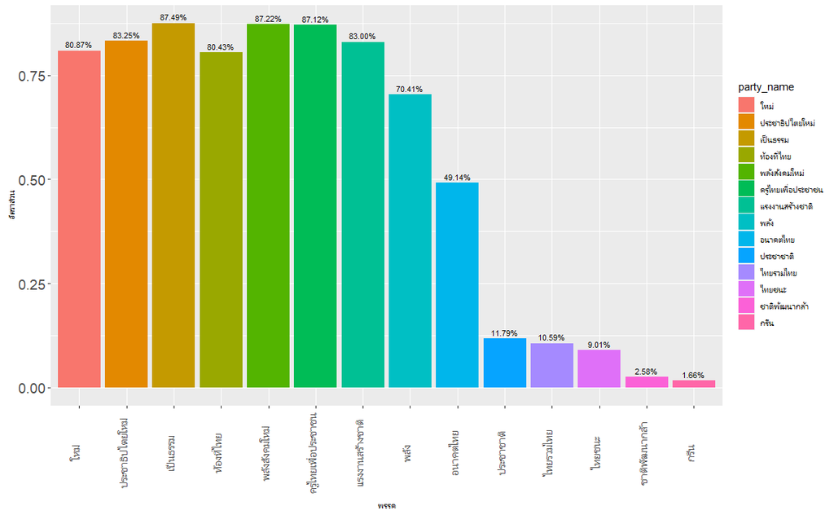

| หมายเลขพรรค | ชื่อพรรค | จำนวนเขตที่ตรง | คะแนนส้มหล่น | คะแนนทั้งหมด | อัตราส่วน | ประมานการณ์ | ส่วนต่าง |
| --- | --- | --- | --- | --- | --- | --- | --- |
| 1 | ใหม่ | 252 | 199,087 | 246,177 | 80.87% | 127,270 | 118,907 |
| 2 | ประชาธิปไตยใหม่ | 267 | 222,098 | 266,799 | 83.25% | 134,439 | 132,360 |
| 3 | เป็นธรรม | 252 | 158,964 | 181,699 | 87.49% | 61,445 | 120,254 |
| 4 | ท้องที่ไทย | 246 | 158,892 | 197,543 | 80.43% | 100,392 | 97,151 |
| 5 | พลังสังคมใหม่ | 267 | 152,550 | 174,897 | 87.22% | 67,209 | 107,688 |
| 6 | ครูไทยเพื่อประชาชน | 253 | 150,679 | 172,963 | 87.12% | 60,636 | 112,327 |
| 8 | แรงงานสร้างชาติ | 224 | 106,729 | 128,586 | 83.00% | 49,675 | 78,911 |
| 9 | พลัง | 151 | 108,848 | 154,602 | 70.41% | 73,500 | 81,102 |
| 10 | อนาคตไทย | 91 | 39,665 | 80,712 | 49.14% | 53,135 | 27,577 |
| 11 | ประชาชาติ | 55 | 67,990 | 576,613 | 11.79% | 589,707 | -13,094 |

[output cut: 4 more lines]

```
รวมทั้งหมด 873678 เสียง
```

> เราพอจะสรุปได้ว่า
> 1. พรรคที่ได้คะแนนส้มหล่นมากที่สุดคือพรรคหมายเลข 1-9
> 2. หมายเลข 10 และ หมายเลข 11 ได้บ้างเพียงเล็กน้อย
> 3. ตั้งแต่ 12 ขึ้นไปแทบจะไม่ได้เลย

# 3 เป็นความบังเอิญจริงๆหรือ

> ที่นี้เรามาลองดูกันอีกมุมหนึ่งว่า พรรคเล็กเหล่านี้ได้คะแนนจากการที่เลขพรรคไปบังเอิญตรงกันกับ เลขผู้สมัคร ส.ส. ของพรรคใหญ่พรรคใดเป็นสัดส่วนเท่าใหร่บ้าง

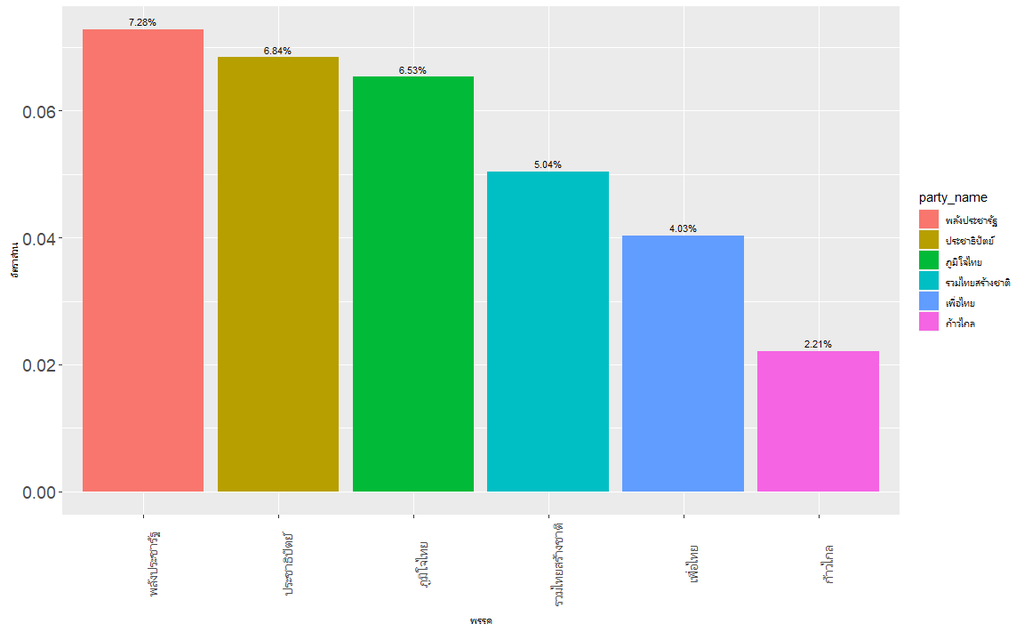

| ตรงกับพรรคใหญ่ | คะแนนเขตพรรคใหญ่ | คะแนนบัญชีรายชื่อพรรคเล็ก | จำนวนเขต | อัตราส่วน |
| --- | --- | --- | --- | --- |
| เพื่อไทย | 8,420,674 | 339,749 | 359 | 4.03% |
| ก้าวไกล | 8,260,753 | 182,687 | 342 | 2.21% |
| ภูมิใจไทย | 4,731,551 | 308,959 | 350 | 6.53% |
| พลังประชารัฐ | 3,617,346 | 263,218 | 354 | 7.28% |
| รวมไทยสร้างชาติ | 3,021,436 | 152,153 | 348 | 5.04% |
| ประชาธิปัตย์ | 1,989,999 | 136,095 | 346 | 6.84% |

> หากคะแนนเหล่านี้ เกิดจากการกาสลับใบจริงๆ แล้วเหตุใดผู้ลงคะแนนเลือก ส.ส. จากก้าวไกลถึงกาสลับใบเพียงแค่ 2.21% แต่ผู้ลงคะแนนเลือก ส.ส. จากพลังประชารัฐ, ภูมิใจไทย, และประชาธิปัตย์จึงได้กาผิดกันมากถึง 6.5 - 7.2%

> จะเป็นไปได้หรือไม่ ถ้ามันไม่ใช่เป็นเพราะกาสลับใบ แต่เป็นเพราะพวกเขาเหล่านั้นตั้งใจกาเบอร์นี้ตั้งแต่แรก

# 4 ทฤษฎีปลอกกระสุน

> ดังที่ผมเขียนไว้ในบทนำว่า “การทุจริตการเลือกตั้งโดยการซื้อเสียงมักจะทำโดยการซื้อเสียง ส.ส. เขตเนื่องจากใช้เงินลงทุนน้อยกว่ามากต่อ 1 ที่นั่งในสภาและชาวบ้านที่ถูกซื้อเสียงเหล่านั้นก็มักจะกาบัตร 2 ใบเป็นเลขเดียวกันเพื่อป้องกันความผิดพลาดและง่ายต่อการจดจำ”

> เมื่อใดก็ตามที่หมายเลขของผู้สมัคร ส.ส. คนใดคนหนึ่งในพรรคใหญ่ไปตรงกับหมาบเลขพรรคของพรรคเล็ก คะแนนของพรรคเล็กเหล่านี้จะเป็นร่องรอยที่เปรียบได้กับปลอกกระสุนดังที่อาจารย์ลอยได้ตั้งชื่อไว้ (ชอบชื่อนี้มาก) หมายความว่าหากเราตามรอยของปลอกกระสุนนี้ไป เราอาจจะไปพบกับเจ้าของปลอกกระสุนนี้ได้ ถึงแม้ว่าเราอาจจะไม่สามารถพิสูจน์ได้ว่าเขาเป็นคนยิงหรือไม่ก็ตาม

> มีขยายความเพิ่มเติมในข้อ 6

## 4.1 ผู้ต้องสงสัย TOP 1%

> จากทั้งหมด 3,200 ตัวอย่าง( 8 พรรคเล็ก พรรคละ 400 เขต) หากเราลองเจาะลึกดูเฉพาะเขตที่พรรคเล็กได้คะแนนเสียงมากเป็นพิเศษ โดยผมจะเลือกมา 32 ตัวอย่างจาก 3,200 (1% จาก 3,200 ตัวอย่าง) โดยเรียงลำดับจากเขตที่พรรคเล็กได้คะแนนบัญชีรายชื่อได้มากที่สุด ไล่ลงไปหาเขตที่ได้คะแนนน้อยที่สุด

> จากทั้งหมด 32 ตัวอย่าง เมื่อเราเอาหมายเลขของพรรคมาหาว่าผู้สมัครท่านใดในเขตนั้นที่มีหมายเลขตรงกัน เราจะได้ผู้สมัครออกมาทั้งหมด 32 คนดังนี้

|  | จังหวัด | เขต | พรรคเล็ก | คะแนนบัญชีรายชื่อ | ตรงกับพรรคใหญ่ | ผู้สมัครหมายเลข | อันดับในเขต |
| --- | --- | --- | --- | --- | --- | --- | --- |
| 1 | อุบลราชธานี | 10 | ใหม่ | 4,598 | เพื่อไทรวมพลัง | 1 | 1 |
| 2 | ตาก | 3 | พลังสังคมใหม่ | 3,931 | พลังประชารัฐ | 5 | 1 |
| 3 | เลย | 3 | ประชาธิปไตยใหม่ | 3,711 | ภูมิใจไทย | 2 | 1 |
| 4 | เชียงใหม่ | 10 | ใหม่ | 3,663 | เพื่อไทย | 1 | 1 |
| 5 | นครสวรรค์ | 4 | ท้องที่ไทย | 3,426 | เพื่อไทย | 4 | 2 |
| 6 | เพชรบูรณ์ | 3 | ประชาธิปไตยใหม่ | 3,419 | พลังประชารัฐ | 2 | 1 |
| 7 | บุรีรัมย์ | 2 | ใหม่ | 3,409 | ภูมิใจไทย | 1 | 1 |
| 8 | เพชรบูรณ์ | 6 | เป็นธรรม | 3,379 | พลังประชารัฐ | 3 | 1 |
| 9 | บุรีรัมย์ | 10 | ประชาธิปไตยใหม่ | 3,322 | ภูมิใจไทย | 2 | 1 |
| 10 | ลพบุรี | 4 | พลังสังคมใหม่ | 3,310 | ภูมิใจไทย | 5 | 1 |

[output cut: 22 more lines]

> เราพบว่าจากผู้สมัครต้องสงสัยสูงสุด 32 คนที่เราเลือกมานั้นมีถึง 30 คนที่ชนะในเขตของตนเอง และอีก 2 คนที่เหลือก็ยังได้อันดับที่ 2 ในเขตนั้นๆ

> หากกวาดตามองผ่านๆก็จะพบว่าชื่อของพรรคภูมิใจไทยและพรรคพลังประชารัฐโผล่ขึ้นมาเต็มไปหมด และเมื่อเราทำตารางสรุปจากข้อมูลข้างต้นจะได้ออกมาดังนี้ครับ

|  | พรรค | จำนวนผู้สมัคร | จำนวนเขตที่ชนะ | คะแนนเขต | คะแนนบัญชีรายชื่อ |
| --- | --- | --- | --- | --- | --- |
| 1 | ภูมิใจไทย | 15 | 15 | 622,675 | 159,185 |
| 2 | พลังประชารัฐ | 9 | 9 | 360,322 | 31,739 |
| 3 | ประชาธิปัตย์ | 3 | 2 | 120,930 | 40,750 |
| 4 | เพื่อไทย | 2 | 1 | 57,668 | 75,479 |
| 5 | ชาติไทยพัฒนา | 2 | 2 | 98,516 | 34,407 |
| 6 | เพื่อไทรวมพลัง | 1 | 1 | 63,127 | 3,964 |

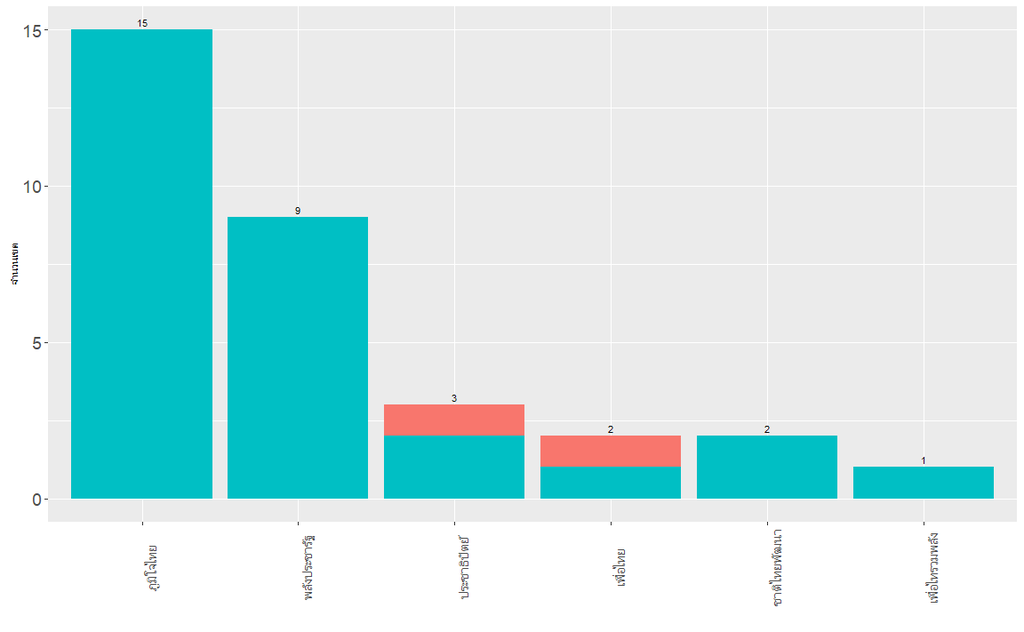

> เราพบผู้สมัครจากพรรคภูมิใจไทยถึง 15 ท่านและผู้สมัครจากพรรคพลังประชารัฐ 9 ท่าน แต่เรากลับไม่พบชื่อผู้สมัครจาก พรรคก้าวไกลเลยแม่แต่ท่านเดียว รวมถึงพรรครวมไทยสร้างชาติด้วย

## 4.2 ผู้ต้องสงสัย TOP 3%

|  | พรรค | จำนวนผู้สมัคร | จำนวนเขตที่ชนะ | คะแนนเขต | คะแนนบัญชีรายชื่อพรรคเล็ก | อัตราส่วน |
| --- | --- | --- | --- | --- | --- | --- |
| 1 | ภูมิใจไทย | 41 | 33 | 1,586,357 | 329,717 | 20.785% |
| 2 | พลังประชารัฐ | 22 | 19 | 838,916 | 80,938 | 9.648% |
| 3 | เพื่อไทย | 16 | 14 | 690,874 | 630,527 | 91.265% |
| 4 | ประชาธิปัตย์ | 8 | 6 | 263,787 | 76,558 | 29.023% |
| 5 | รวมไทยสร้างชาติ | 4 | 3 | 144,858 | 70,834 | 48.899% |
| 6 | ชาติไทยพัฒนา | 3 | 3 | 138,231 | 38,127 | 27.582% |
| 7 | ชาติพัฒนากล้า | 1 | 0 | 31,768 | 8,735 | 27.496% |
| 8 | เพื่อไทรวมพลัง | 1 | 1 | 63,127 | 3,964 | 6.279% |

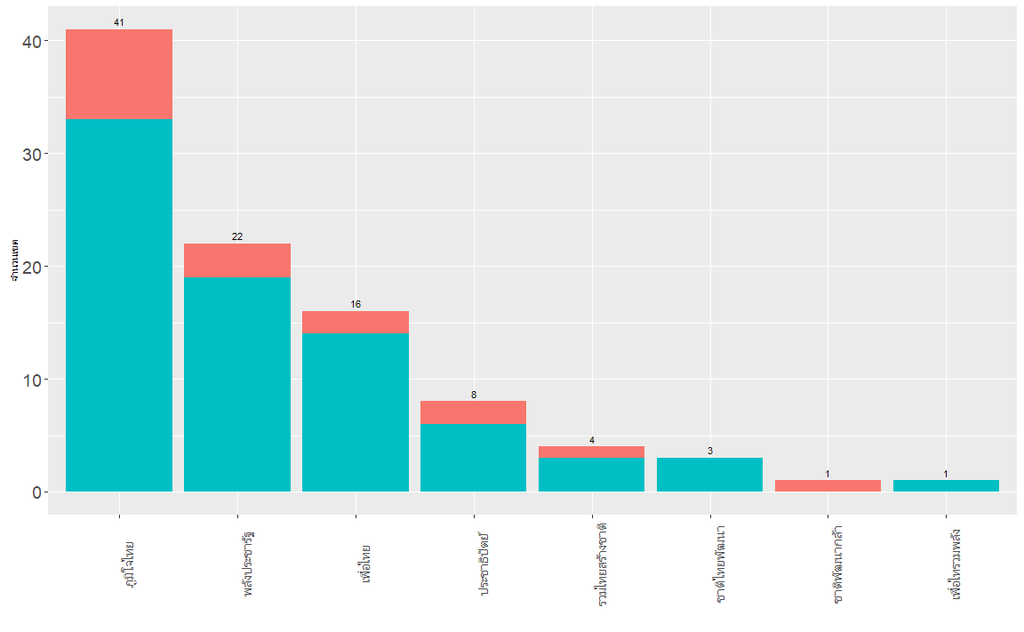

## 4.3 ผู้ต้องสงสัย TOP 5%

|  | พรรค | จำนวนผู้สมัคร | จำนวนเขตที่ชนะ | คะแนนเขต | คะแนนบัญชีรายชื่อพรรคเล็ก | อัตราส่วน |
| --- | --- | --- | --- | --- | --- | --- |
| 1 | ภูมิใจไทย | 61 | 46 | 2,284,389 | 439,499 | 19.24% |
| 2 | พลังประชารัฐ | 37 | 26 | 1,281,258 | 129,307 | 10.09% |
| 3 | เพื่อไทย | 32 | 29 | 1,376,417 | 1,258,974 | 91.47% |
| 4 | ประชาธิปัตย์ | 10 | 6 | 312,178 | 89,375 | 28.63% |
| 5 | รวมไทยสร้างชาติ | 9 | 7 | 338,460 | 161,342 | 47.67% |
| 6 | ชาติไทยพัฒนา | 6 | 6 | 256,826 | 67,871 | 26.43% |
| 7 | ชาติพัฒนากล้า | 3 | 1 | 87,073 | 18,092 | 20.78% |
| 8 | ไทยสร้างไทย | 2 | 2 | 89,380 | 17,666 | 19.77% |
| 9 | เพื่อไทรวมพลัง | 1 | 1 | 63,127 | 3,964 | 6.28% |

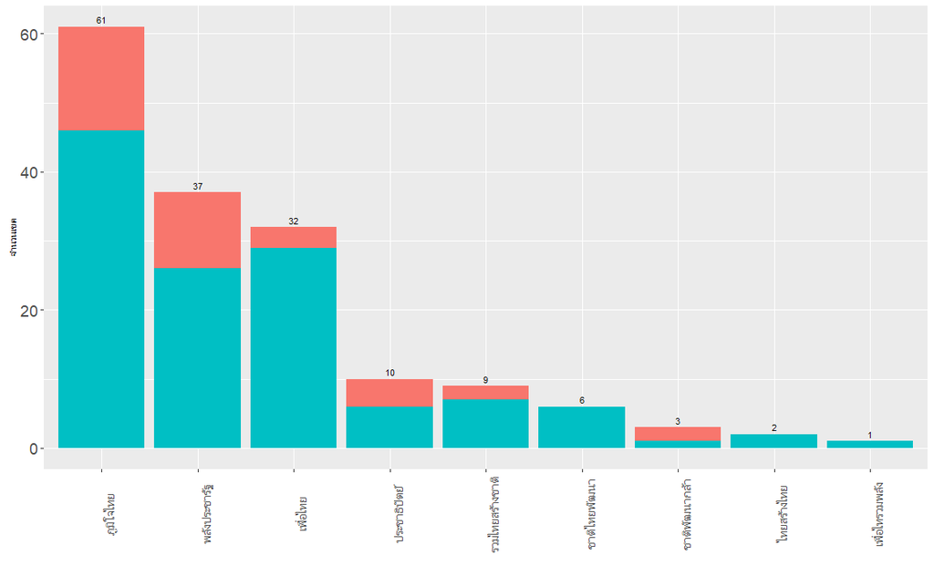

## 4.4 ข้อสรุปจากกลุ่มตัวอย่าง

> จาก 160 ตัวอย่างเรากลับไม่พบผู้ต้องสงสัยมาจากพรรคก้าวไกลเลยแม้แต่ท่านเดียว

> ทั้งๆที่พรรคก้าวไกลได้คะแนนรวมของ ส.ส. เขตมากที่สุดเป็นอันดับ 1 หากไม่มีการทุจริตใดๆเกิดขึ้นในการเลือกตั้งครั้งนี้ คะแนนที่จะถูกโยนไปให้บัญชีรายชื่อของพรรคเล็กเนื่องจากการกาสลับใบ ควรมาจากพรรคก้าวไกลมากที่สุด แต่ใน 160 ผู้ต้องสงสัยนี้ กลับไม่มีผู้สมัครพรรคก้าวไกลเลยแม้แต่ท่านเดียว ถึงแม้เราอาจจะไม่สามารถสรุปใด้แบบมั่นใจ 100% แต่มีความเป็นไปได้สูงมากที่ผู้สมัครทั้ง 160 ท่านนี้อาจจะเป็นเจ้าของปลอกกระสุนที่พวกเราเจอ

## 4.5 การกระจายตัวของข้อมูล

> ถ้าถึงตรงนี้แล้วคุณยังไม่เชื่อว่าโอกาสที่จะชนะการเลือกตั้งภายในเขตมีความสัมพันธ์กับคะแนนของพรรคเล็ก ให้ลองดูกราฟด้านล่างนี้ครับ

> 1 จุดแทนด้วย 1 ผู้สมัคร สีฟ้าคือชนะในเขต สีแดงคือแพ้ในเขต

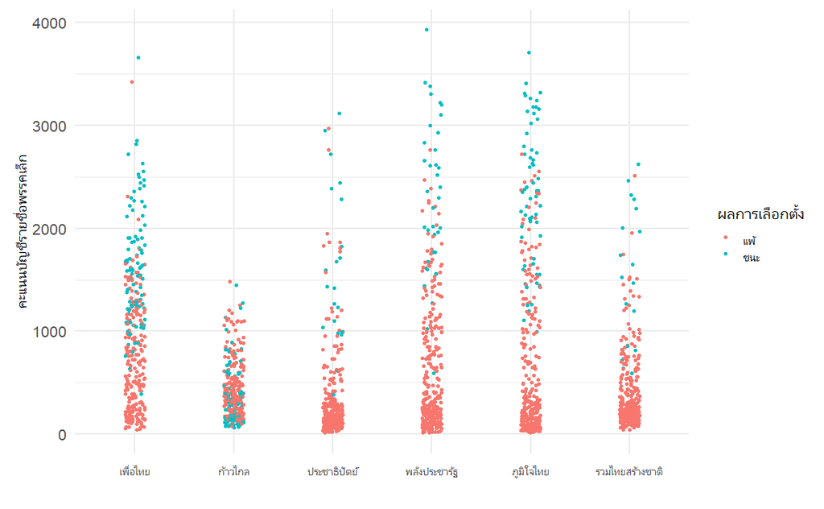

# 5 การคำนวนหาจำนวนกระสุนทั้งหมด

> หากเรานำผู้ต้องสงสัยทั้งหมด 3200 ผู้สมัคร แล้วคัดออกเหลือที่เป็นผู้สมัครพรรคใหญ่ 6 พรรค เราจะเหลือผู้ต้องสงสัยทั้งหมด 1,912 ท่าน โดยแบ่งออกเป็นผู้สมัครจากแต่ละพรรคได้ดังนี้

|  | พรรค | จำนวนผู้สมัคร |
| --- | --- | --- |
| 1 | ภูมิใจไทย | 320 |
| 2 | รวมไทยสร้างชาติ | 315 |
| 3 | ประชาธิปัตย์ | 315 |
| 4 | เพื่อไทย | 319 |
| 5 | ก้าวไกล | 316 |
| 6 | พลังประชารัฐ | 327 |

## 5.1 ผู้สมัครต้องสงสัยทั้งหมด VS ตัวชี้วัดต่างๆ

> อันดับต้องสงสัยภายในพรรค = นำผู้ต้องสงสัยทั้งหมดมาจับเรียงตามคะแนนปาร์ตี้ลิสต์ของพรรคเล็กที่มีหมายเลขตรงกันกับผู้สมัครคนนั้น ( อันดับต้องสงสัย 1 ถึง 1,912 )

> ที่นั่งสะสม = จำนวนที่นั่งสะสมที่พรรครวบรวมได้

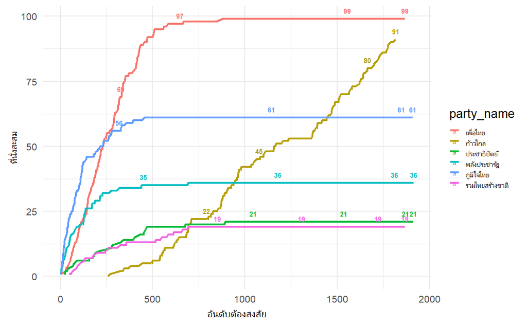

## 5.2 อันดับต้องสงสัยภายในพรรค VS เขตที่ชนะสะสม

> อันดับต้องสงสัยภายในพรรค = นำผู้ต้องสงสัยแยกตามแต่ละพรรคมาจับเรียงตามคะแนนปาร์ตี้ลิสต์ของพรรคเล็กที่มีหมายเลขตรงกันกับผู้สมัครคนนั้น ( อันดับต้องสงสัย 1 ถึง 300 กว่าๆ )

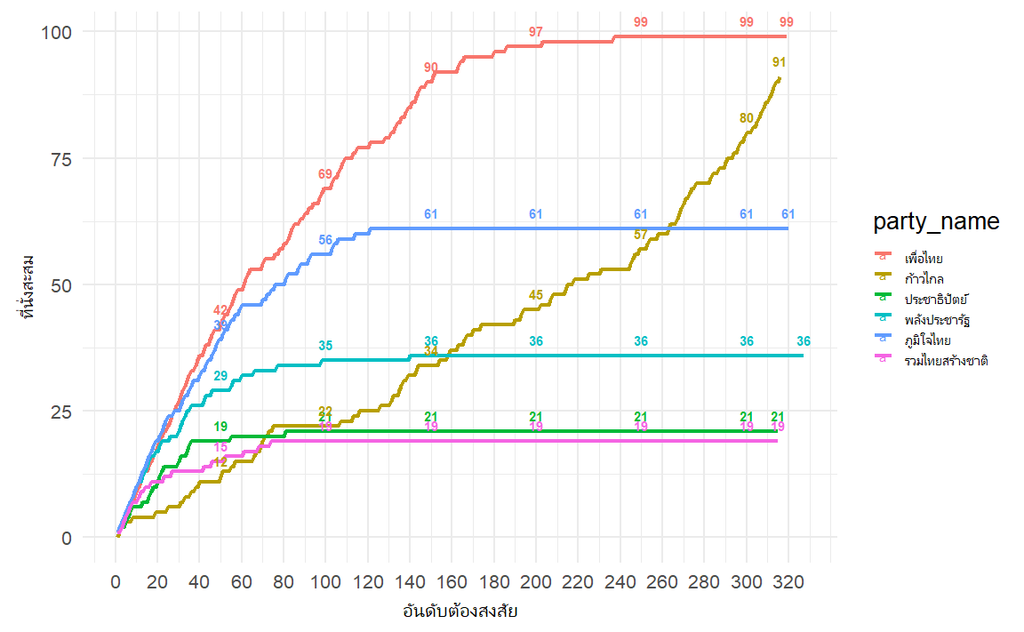

## 5.3 อันดับต้องสงสัยภายในพรรค VS คะแนนบัญชีรายชื่อพรรคเล็ก

> คะแนนบัญชีรายชื่อพรรคเล็ก = คะแนนปาร์ตี้ลิสต์ของพรรคเล็กที่มีหมายเลขตรงกันกับผู้สมัครในพรรคนั้นๆ

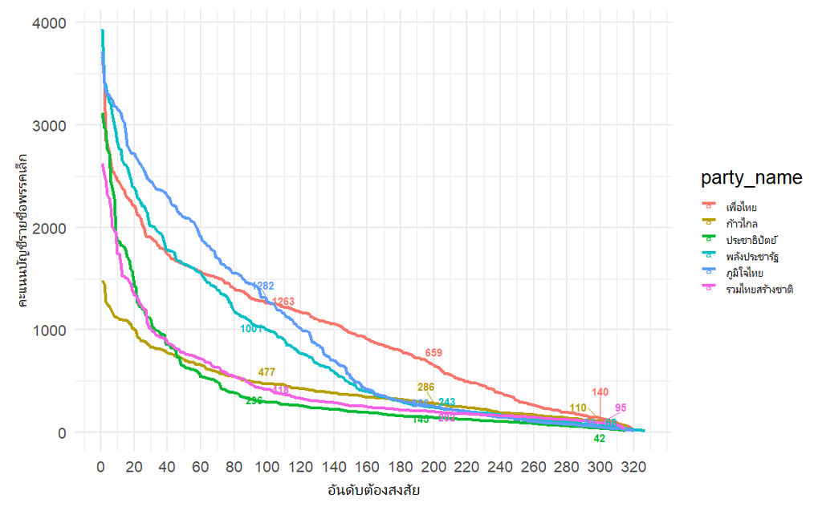

## 5.4 อันดับต้องสงสัยภายในพรรค VS % ส่วนแบ่งคะแนนบัญชีรายชื่อพรรคเล็กในเขต

> % ส่วนแบ่งคะแนนบัญชีรายชื่อพรรคเล็กในเขต = คะนนบัญชีรายชื่อพรรคเล็กหารด้วยคะแนนบัญชีรายชื่อของทุกพรรครวมกันในเขตนั้นๆ

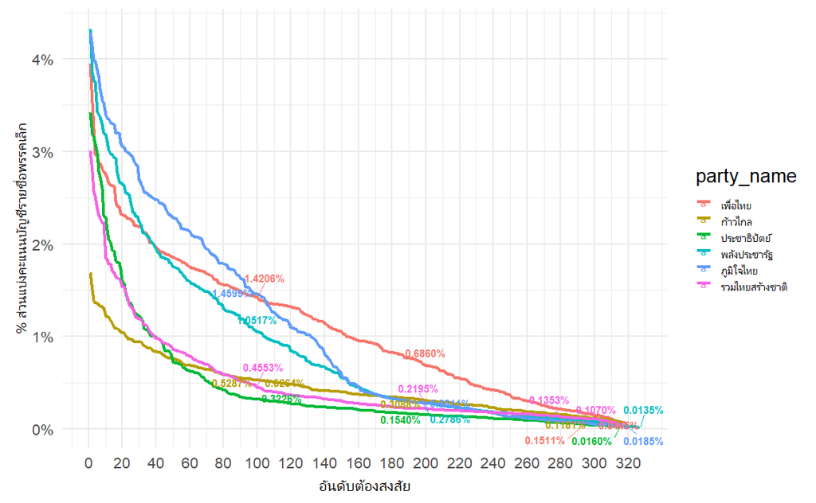

> คะแนนเขตสะสม = คะแนน ส.ส. เขตที่พรรครวบรวมได้

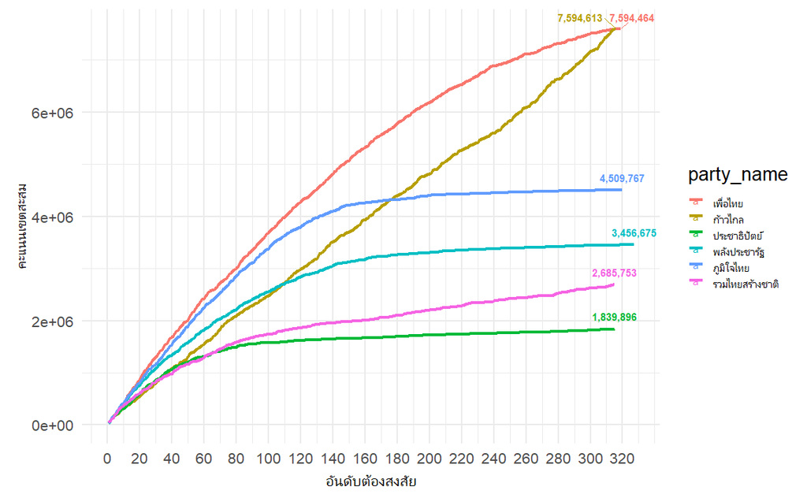

## 5.6 คำนวนกระสุนทั้งหมด

> เราสามารถอนุมานจำนวนเขตและคะแนนที่มีการสาดกระสุนได้ด้วยหลากหลายวิธีจากการสังเกตุลักษณะของการเปลี่ยนแปลงในธรรมชาติของกราฟเช่น

> พรรคภูมิใจไทย
> - จากกราฟ 5.2 สสคนสุดท้ายที่ได้ที่นั่ง ตำแหน่งประมาน 120
> - จากกราฟ 5.3 หัวเริ่มหักลงมาตั้งแต่ประมานตำแหน่งที่ 1ุ60 และแบนราบออก
> - จากกราฟ 5.4 หัวเริ่มหักลงมาตั้งแต่ประมานตำแหน่งที่ 160 และแบนราบออก
> - จากกราฟ 5.5 หัวเริ่มหักลงมาตั้งแต่ประมานตำแหน่งที่ 150 และแบนราบออก
> - อนุมานได้ว่าพรรคภูมิใจไทยมีการสาดกระสุนประมาน 120-160 เขต

> พรรครวมไทยสร้างชาติ
> - จากกราฟ 5.2 สสคนสุดท้ายที่ได้ที่นั่ง ตำแหน่งประมาน 75
> - จากกราฟ 5.3 หัวเริ่มหักลงมาตั้งแต่ประมานตำแหน่งที่ 80 และแบนราบออก
> - จากกราฟ 5.4 หัวเริ่มหักลงมาตั้งแต่ประมานตำแหน่งที่ 100 และแบนราบออก
> - จากกราฟ 5.4 หัวเริ่มหักลงมาตั้งแต่ประมานตำแหน่งที่ 100 และแบนราบออก
> - อนุมานได้ว่าพรรครวมไทยสร้างชาติมีการสาดกระสุนประมาน 75-100 เขต

> พรรคประชาธิปัตย์
> - จากกราฟ 5.2 สสคนสุดท้ายที่ได้ที่นั่ง ตำแหน่งประมาน 80
> - จากกราฟ 5.3 หัวเริ่มหักลงมาตั้งแต่ประมานตำแหน่งที่ 90 และแบนราบออก
> - จากกราฟ 5.4 หัวเริ่มหักลงมาตั้งแต่ประมานตำแหน่งที่ 90 และแบนราบออก
> - จากกราฟ 5.5 หัวเริ่มหักลงมาตั้งแต่ประมานตำแหน่งที่ 90 และแบนราบออก
> - อนุมานได้ว่าพรรคประชาธิปัตย์ไทยมีการสาดกระสุนประมาน 80-90 เขต

> พรรคก้าวไกล
> - จากกราฟ 5.2 เทรนกราฟเป็นเส้นตรง = 0
> - จากกราฟ 5.3 หัวเริ่มหักลงมาตั้งแต่ประมานตำแหน่งที่ 40 และแบนราบออก
> - จากกราฟ 5.4 หัวเริ่มหักลงมาตั้งแต่ประมานตำแหน่งที่ 40 และแบนราบออก
> - จากกราฟ 5.5 เทรนกราฟเป็นเส้นตรง = 0
> - อนุมานได้ว่าพรรคก้าวไกลมีการสาดกระสุนประมาน 0-40 เขต

> พรรคพลังประชารัฐ
> - จากกราฟ 5.2 สสคนสุดท้ายที่ได้ที่นั่ง ตำแหน่งประมาน 140
> - จากกราฟ 5.3 หัวเริ่มหักลงมาตั้งแต่ประมานตำแหน่งที่ 160 และแบนราบออก
> - จากกราฟ 5.4 หัวเริ่มหักลงมาตั้งแต่ประมานตำแหน่งที่ 160 และแบนราบออก
> - จากกราฟ 5.5 หัวเริ่มหักลงมาตั้งแต่ประมานตำแหน่งที่ 150 และแบนราบออก
> - อนุมานได้ว่าพรรคพลังประชารัฐมีการสาดกระสุนประมาน 140-160 เขต

## 5.7 ความเป็นไปได้ของจำนวนกระสุน

|  | พรรค | จำนวนเขตต่ำสุด | จำนวนเขตสูงสุด | จำนัวนที่นั่งต่ำสุด | จำนวนที่นั่งสูงสุด | ซื้อเสียงจำนวนต่ำสุด | ซื้อเสียงจำนวนสูงสุด |
| --- | --- | --- | --- | --- | --- | --- | --- |
| 1 | ภูมิใจไทย | 120 | 160 | 60 | 61 | 239,317 | 267,347 |
| 2 | รวมไทยสร้างชาติ | 75 | 100 | 19 | 19 | 83,887 | 96,216 |
| 3 | ประชาธิปัตย์ | 80 | 90 | 20 | 21 | 87,276 | 90,798 |
| 4 | เพื่อไทย | 175 | 300 | 95 | 99 | 258,055 | 311,108 |
| 5 | ก้าวไกล | 0 | 40 | 0 | 11 | 0 | 40,284 |
| 6 | พลังประชารัฐ | 140 | 160 | 36 | 36 | 213,075 | 222,660 |

```
อาจมีการซื้อเสียงรวมกันมากถึง 881,610 ไปจนถึง 1,028,413 เสียง
```

> ซึ่งได้ตัวเลขออกมาใกล้เคียงกับตัวเลข 873,678 เสียงที่เราคาดการณ์ไว้ที่ข้อ 2.3

# 6 correlation or causation

> เนื้อหาส่วนนี้เขียนขึ้นมาเพิ่มเติมภายหลัง เนื่องจากมีหลายท่านที่สงสัยว่ามันเป็น Correlation หรือ Causation กันแน่

> หรือพูดอีกอย่างคือการกาสลับใบอาจจะเป็นเพราะผู้ที่ลงคะแนนเลือกแต่ละพรรคอาจจะมีพื้นฐานด้าน Demographic ที่แตกต่างกันซึ่งหากเป็นเช่นนั้นจริงแปลว่า ผู้ลงคะแนนให้พรรคเดียวกันในจังหวัดเดียวกัน แต่แตกต่างกันเพียงที่หมายเลขเขตก็ควรจะมีธรรมชาติของข้อมูลที่คล้ายๆกัน อัตราการกาสลับก็ควรจะใกล้เคียงกัน คะแนนบัญชีรายชื่อของพรรคเล็กก็ควรจะใกล้เคียงกันเช่นกัน

> ผมจึงเอาข้อมูลมาปรียบเทียบดูผู้สมัครจากพรรคเดียวกันในจังหวัดเดียวกัน และเปรียบเทียบคะแนนบัญชีรายชื่อของพรรคเล็กในเขตที่ผู้สมัครที่ชนะการเลือกตั้งเปรียบเทียบกับผู้สมัครที่แพ้การเลือกตั้ง

> ** ข้อมูลเฉพาะจังหวัดที่มีทั้งเขตแพ้และชนะในพรรคและจังหวัดเดียวกันจาก 1,912 ตัวอย่างเดียวกับกราฟด้านบน

> ตารางนี้เป็น Interactive Data สารมารถคลิกเข้าไปกรองดูได้

> คะแนนเฉลี่ยในตารางนี้คือคะแนนบัญชีรายชื่อพรรคเล็ก

> อัตราส่วนคือเอาคะแนนเฉลี่ยในเขตที่แพ้ / คะแนนเฉลี่ยในเขตที่ชนะ ตัวเลขยิ่งน้อยแปลว่าเขตที่แพ้จะกาสลับใบน้อยเมื่อเทียบกับเขตที่ชนะ

|  | พรรค | จังหวัด | จำนวนเขตที่ชนะ | คะแนนเฉลี่ย | จำนวนเขตที่แพ้ | คะแนนเฉลี่ย | อัตราส่วน |
| --- | --- | --- | --- | --- | --- | --- | --- |
| 1 | ก้าวไกล | กรุงเทพมหานคร | 22 | 131 | 1 | 181 | 138.168% |
| 2 | ก้าวไกล | ขอนแก่น | 3 | 551 | 4 | 454 | 82.396% |
| 3 | ก้าวไกล | ฉะเชิงเทรา | 1 | 597 | 3 | 552 | 92.462% |
| 4 | ก้าวไกล | ชลบุรี | 5 | 159 | 3 | 292 | 183.648% |
| 5 | ก้าวไกล | นครปฐม | 2 | 244 | 4 | 308 | 126.230% |
| 6 | ก้าวไกล | นครราชสีมา | 2 | 485 | 11 | 330 | 68.041% |
| 7 | ก้าวไกล | นครสวรรค์ | 1 | 565 | 4 | 374 | 66.195% |
| 8 | ก้าวไกล | ปทุมธานี | 5 | 216 | 1 | 145 | 67.130% |
| 9 | ก้าวไกล | ปราจีนบุรี | 1 | 66 | 1 | 472 | 715.152% |
| 10 | ก้าวไกล | พระนครศรีอยุธยา | 1 | 377 | 2 | 283 | 75.066% |

[output cut: 102 more lines]

> Visualize การกระจายตัวของข้อมูลโดย 1 จุดคือ 1 จังหวัด

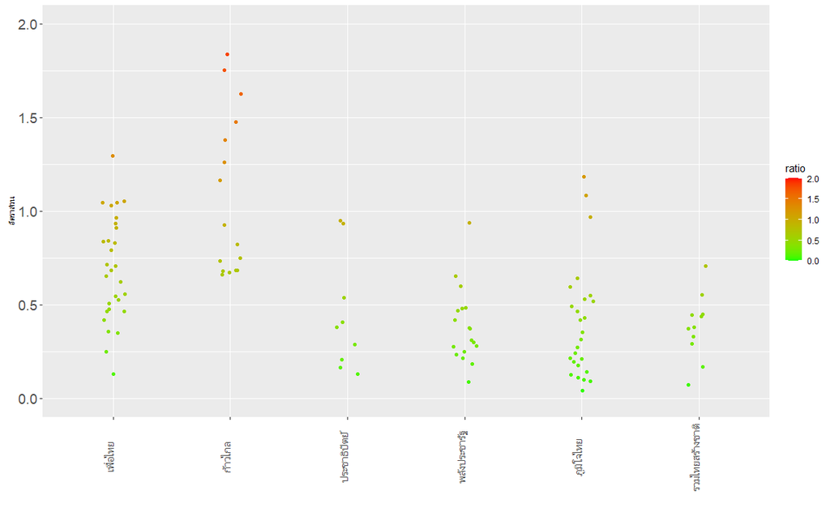

> สรุปออกมาเป็นรายพรรค

|  | พรรค | จำนวนเขตที่ชนะ | คะแนนเฉลี่ย | จำนวนเขตที่แพ้ | คะแนนเฉลี่ย | อัตราส่วน |
| --- | --- | --- | --- | --- | --- | --- |
| 1 | ก้าวไกล | 91 | 367 | 225 | 446 | 121.53% |
| 2 | ประชาธิปัตย์ | 21 | 1626 | 294 | 308 | 18.94% |
| 3 | พลังประชารัฐ | 36 | 2322 | 291 | 575 | 24.76% |
| 4 | ภูมิใจไทย | 61 | 2334 | 259 | 587 | 25.15% |
| 5 | รวมไทยสร้างชาติ | 19 | 1531 | 296 | 376 | 24.56% |
| 6 | เพื่อไทย | 99 | 1620 | 220 | 692 | 42.72% |

# 7 อาจมีเขียนเพิ่มเติมไปเรื่อยๆ

# 8 บทสรุป

> ประมาณการว่ามีการสาดกระสุนที่เข้าเป้า **อย่างๆน้อยๆ** 8 แสนไปจนถึง 1 ล้านนัดทั่วประเทศ ตีมูลค่าได้นับพันล้านบาท

> แต่ไม่ได้แปลว่าจะมีการสาดกระสุนกันเพียง 800,000-1,000,000 นัด อาจจะยังมีกระสุนอีกมากที่เรายังไม่พบ อาจจะมีที่ยิงแล้วไม่เข้าเป้า หรือมือปืนรับจ้างเก็บกระสุนไปโดยไม่บอกนายแต่อ้างว่ายิงไปแล้ว ซึ่งตัวเลขอาจจะมากกว่านี้เป็นเท่าตัว เรายังไม่อาจทราบได้จากร่องลอยเหล่านี้

> พรรคก้าวไกลอาจจะเป็นเป็นพรรคที่ใสสะอาดที่สุดในทั้งหมด 6 พรรคใหญ่ ไม่พบความสัมพันธ์ระหว่างคะแนนพรรคเล็กและเสียงคะแนน สส เขต แต่ก็ไม่สามารถสรุปได้ว่าพรรคก้าวไกลไม่มีการซื้อเสียง เพียงแต่ว่าเรายังไม่พบปลอกกระสุนเท่านั้นเอง

> นอกจากพรรคก้าวไกลแล้ว อีก 5 พรรคที่เหลือมีรูปแบบที่ชัดเจนคือ มักจะได้ที่นั่ง สส ในเขตต้องสงสัยกันทั้งสิ้น มีความสัมพันธ์ระหว่างคะแนนของพรรคเล็กและโอกาสที่จะชนะในเขตอย่างชัดเจน เพียงแต่อาจจะมีกลยุทธ์การยิงที่แตกต่างกันออกไป

> พรรคเพื่อไทยเป็นพรรคที่มีผลลัพธ์ที่น่าแปลกใจที่สุดในทั้ง 6 พรรคจากข้อมูลชี้ให้เห็นว่า พรรคเพื่อไทยมีโอกาสที่จะสาดกระสุนแทบทุกเขตการเลือกตั้ง เราปฏิเสธไม่ได้เลยว่าคะแนนพรรคเล็กมีความสัมพันธ์กับหมายเลขผู้สมัครของพรรคเพื่อไทยอย่างมีนัยยะสำคัญ

> ส่วนตัวแล้วผมไม่เชื่อว่าจะมีพรรคการเมืองใหนที่จะสามารถการสาดกระสุนไปได้ถึง 300 เขตทั่วประเทศ แต่ อย่างไรก็ตามผมก็ยังไม่สามารถหาคำตอบหรือเหตุผลมาโต้แย้งข้อสรุปตรงนี้ได้

> ทั้งหมดนี้เป็นเพียงแค่การคาดการณ์ทางคณิตศาสตร์เท่านั้น

> **การวิเคราะห์ทั้งหมดนี้ ยังไม่ได้มีการทวนสอบโค้ดและตัวเลขอย่างถี่ถ้วน**

> เขียนโดย: ภูมิใจ ฉัตรไมตรี 24 พ.ค. 2566